# Analysis of Official Data Related to COVID-19 Vaccine Efficacy and Safety

Last updated: February 15, 2022

**Disclaimer**: The authoritative source for COVID-19 information is [Canada.ca/coronavirus](https://www.canada.ca/en/public-health/services/diseases/coronavirus-disease-covid-19.html). The results and views presented in this portal are those by the authors and are not to be misconstrued as representing views of any Canadian Agency, University, or Department. They were developed and gathered by the [R4GC Data Science community](https://open-canada.github.io/r4gc/index.html#r4gc-community) as part of the community training and socializing, mostly on authors’ own time and using authors’ own resources. All codes behind the analysis and supporting documents are free, open and available in [GitHub](https://github.com/open-canada/vitals/).

### Raison d’être

On March 31, 2021, just before COVID-19 vaccination of general public commenced, the Chief Science Advisor of Canada in its ["*Scientific Considerations for Using COVID-19 Vaccination Certificates"*](https://science.gc.ca/eic/site/063.nsf/eng/h_98229.html) report has expressed several concerns and recommendations related to the uncertanties associated with using new COVID-19 vaccines that were approved under Emergercy Act and did not go through all normally conducted testing stages, which include the following:

- Scientific uncertainties: *Given the short time since the COVID-19 vaccines have become available, it is not surprising that many scientific uncertainties persist and are the subject of intense ongoing studies*.
- Ethical and Social Considerations: *It should also be noted that while the anticipation of more freedom may be an incentive for some to get vaccinated, vaccine acceptance could decrease in others if there was a sense of coercion tied to using vaccination certificates.*
- Legal Considerations: *The processes by which vaccine certificates are issued and controlled need to be fraud proof*
- Conclusion: *[All levels of government could work to develop a framework that] Maximizes consistent post-vaccine monitoring*

- Priority actions moving forward: *The emerging issue of vaccine associated heart disease requires attention on two important levels: addressing data and knowledge gaps on the one hand, and promoting awareness and clinical care on the other.*

It could have been expected that there would more reports produced from the Chief Science Advisor Office to follow up on their own recommendations of “addressing data and knowledge gaps” and “promoting awareness”, as more and more data just stated to be avalailable after July (especially after October 2021, when vaccination rate reached 75% and vital statistics (deaths) data has finally become available), and yet there were none produced, as of Februarry 2020 – more than half a year after the previous report was issued.

It is not clear why. Equally it is not clear, why there is still not a single other publication or COVID-19 vaccine training produced by the Goverment of Canada that would be based on the data obtained *after* the commencement of general public vaccination (i.e., after May and which has become avialable in public domain after October 2021), not prior to it. Numerous requests for such information were made. In the absense to the official published analysis of the latest data, a group of data scientists from across several Goverment of Canada departments decided to conduct such analysis themselves, as part of their weekly data science training and driven by the desire to apply their new skills for public good, while also helping each other, as some members of the group experienced long-lasting (albeit called “non-serious”) vaccine side effects that, they found, very difficult to report.

This portal started as a result of these efforts. It provides links to related Open Canada sources and datasets, [Guidelines for reporting vaccine side-effects](https://ivi-m.github.io/vv/report-side-effect), an interactive [Open Canada Vital Statistics (Death) Tracking application](https://open-canada.github.io/Apps/vitals) built by the community, and the Observations made from the analysis for sharing with the public and policy-makers for greater awareness and further validation – in line with the recommendations of the Office of the Chief Science Advisor and the [Scientific Integrity Policy](https://science.gc.ca/eic/site/063.nsf/eng/h_98027.html) they developed.

### Observations

- Open Canada data that has become available *after* the start of general public vaccination do not support the COVID-19 vaccine manufacturers' claims about vaccine efficacy and safety.
- Firstly, the number of serious COVID-19 adverse events already reported, including deaths and key organs failures, appears to be much higher than what should be expected from a “safe” vaccine, being comparable to (and for certain populations higher than) the number of COVID-19 deaths alone.
- Secondly, it is observed that certain reports produced by the Government of Canada (PHAC ‘Cases following vaccination’ reports) contain algorithmic bias that skews the results considerably in the favour of vaccine manufacturers’ claims.
- When recomputed without the embedded bias, the reported data do not support the claims made in those reports that *“Fully vaccinated individuals diagnosed with COVID-19 were significantly protected from severe outcomes.”*. In fact, they support exactly the opposite: that as since December, *Fully vaccinated individuals diagnosed with COVID-19 were twice as much less protected from severe outcomes, compared to unvaccinated individuals*
  - All codes, spreadsheets, and archived PHAC reports (since July 2021, which is when PHAC they started reporting ‘Cases by vaccination status’ statistics), from which the raw data were extracted, are available [here](https://github.com/IVI-M/vv/tree/main/docs/COVID-19%20epidemiology%20updates).
  - Below is a one-slide summary of the result. A PDF version of it with clickable links is available here

[figure not shown]

The following tools and white papers have been prepared to facilitate the discussion.

### Interactive Apps:

- Interactive *Open Canada Vitals Statitistcs (Deaths) Tracker* App: https://open-canada.github.io/Apps/vitals (mirror: https://o-canada.shinyapps.io/vitals).

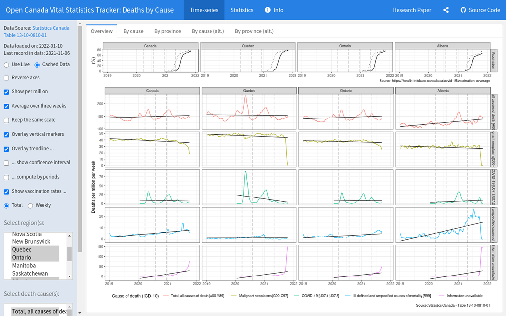

### Self-help tools:

- [Guide on how to report COVID-19 vaccine side-effects in Canada as a consumer](https://ivi-m.github.io/vv/report-side-effect)
- [Early COVID-19 Treatment Guidelines](https://worldcouncilforhealth.org/resources/early-covid-19-treatment-guidelines-a-practical-approach-to-home-based-care-for-healthy-families/)

### White Papers:

- [“Additional observations related to the ‘Elephant in the Room’ – from the Government of Canada COVID-19 daily epidemiology updates. Time to act!”](https://ivi-m.github.io/vv/comment2.pdf), White paper (10 February 2022)
- [“Some observations from Canadian Vital Statistics Death (CVSD) Database related to the ‘Elephant in the Room’”](https://ivi-m.github.io/vv/comment.pdf), Comment submission to The Lancet Journal (6 January 2022)
- [“Statistical analysis of the official data sources related to vaccine efficacy and safety (NEW EVIDENCE SINCE OCTOBER 2021)”](https://ivi-m.github.io/vv/analysis), Additional details (14 January 2022)
- [“One Year since Vaccination. What we have learnt - using Open Canada Data and Data Science”](https://ivi-m.github.io/vv/OneYearOfVaccineInCanada-deck-meetup-2022-02-04.pdf), Special Edition presentation for the R4GC Community ‘Lunch and Learn’ Meetup by the [R4GC Data Science community](https://open-canada.github.io/r4gc/index.html#r4gc-community) lead, Senior Data Scientist, [Dr. Dmitry Gorodnichy](http://gorodnichy.ca) (4 February 2022).

[figure not shown]

## Sources:

[gc1] **Cases following vaccination, COVID-19 Daily Epidemiology Update, Public Health Agency of Canada**, https://health-infobase.canada.ca/covid-19/epidemiological-summary-covid-19-cases.html#a9 ([archived reports](https://github.com/open-canada/vitals/tree/main/docs/COVID-19%20epidemiology%20updates))

[figure not shown]

##### Death cases by vaccination status, biased reporting (from December 14, 2020 to present)

- *on February 10, 2022 for cases from December 14, 2020 up until January 22, 2022 (n=1,670,682)*  
  unvaccinated 68.1%% vs. fully vaccinated **19.5%** (+2.7% increase since last week)
- *on February 04, 2022 for cases from December 14, 2020 up until January 15, 2022 (n=1,458,433)*  
  unvaccinated 70.3% vs. fully vaccinated **16.8%** (+3% increase since last week)
- *on January 21, 2022 for cases from December 14, 2020 up until January 08, 2022 (n=1,341,192)*:  
  unvaccinated 72.8% vs. fully vaccinated **13.8%** (+4.3% increase since December 14)
- *on December 15, 2021 for cases from December 14, 2020 up until November 27, 2021 (n=882,988)*:  
  unvaccinated 76.1% vs. fully vaccinated **9.5%**

NB: The statistics above is quoted directly from the source, where it was computed using death data *since December 2020*, when there were no fully vaccinated Canadians yet (more exactly: there were 0 fully-vaccinated in December, < 1% for most of January, <3% until May). This is known as *algorithmic bias*, which skews results favourably towards fully-vaccinated cases. This bias can be removed using the technique described in [this paper](https://ivi-m.github.io/vv/comment2.pdf). The unbiased statistics are shown below.

##### Infected cases by vaccination status, unbiased reporting (from December 04, 2021 to January 15, 2022)

- The number of COVID-19 cases fully-vaccinated vs. unvaccinated and partially-vaccinated  
  87% vs. 11% and 2%
- For comparison, the vaccination rates in the same period: fully vaccinated vs. unvaccinated and partially-vaccinated:  
  77% vs. 18% and 5%

[figure not shown]

[ gc2 ] **Reported side effects following COVID-19 vaccination in Canada, Canadian COVID-19 vaccination safety report, Public Health Agency of Canada**, https://health-infobase.canada.ca/covid-19/vaccine-safety (Figure 1, Table 1)

**Adverse reactions from COVID-19 vaccines**

Total (since Jan 2021): - All reported adverse reactions: 36,164 - Serious adverse reactions: 7,678. (118 / week)

Between May 2021 and October 2021 (for benchnarking against COVID-19 deaths in the same period - see below) - Serious adverse reactions: **5200** (NB: increased from 5038 posted in last month report) - Of these: 1,111 heart diseases (including 64 Cardiac arrests, 77 Heart Attacks, 970 Myocarditis1/Pericarditis), 947 thrombosis, 781 central nervous system failures (including 594 Bell’s Palsy), 487 Anaphylaxis, 166 Auto-immune diseases, 37 Acute kidney injury, 25 Liver injury, and 208 deaths (some under investigation). - Many are not reported or published yet. According to Health Canada , filing of a report takes three months (in practice, longer than that).

[figure not shown]

[ gc3 ] **Statistics Canada, Canadian Vital Statistics - Death database. Provisional weekly death counts, by selected grouped causes of death**, https://www150.statcan.gc.ca/t1/tbl1/en/tv.action?pid=1310081001 ([App Calculator](https://o-canada.shinyapps.io/vitals/#section-statistics), Last record: November 6, 2021):

**Deaths of COVID-19**

Between December 2020 to April 2021 (from the day first vaccination started to when vaccination rate reached 3%) - COVID-19 deaths: : 13075

Between May 2021 and October 2021 (for benchmarking against health damages caused by COVID-19 vaccine - see above) - COVID-19 deaths: **2975** - COVID-19 deaths without comorbidities: **404** (recomputed using [ukg1]) - COVID-19 deaths without comorbidities for <65 : **89** (recomputed using [ukg1])

- For comparison — Cancer: 27805, Heart: 16605, Accidents: 3380, Suisides: 555

[figure not shown]

Observations of the following anomalies (possibly, “new normals”) are made:

- The total number of deaths in last two years is comparable to (and in some provinces lower than) their five-year average
- At the start of pandemic, when policies among the provinces varies, there was practically no “first wave” observed in Western provinces
- Since the start of pandemic, the number of all non-COVID deaths started to decline
- Sharp increase in the number of unexplained deaths since May 2021, and finally
- Increased delay in reporting deaths: from 2 months to 3 (and in some provinces to 6) months

[ gc4 ] **Recalls and safety alerts, Government of Canada**, https://recalls-rappels.canada.ca/: (for [[Moderna](https://recalls-rappels.canada.ca/en/search/site?search_api_fulltext=moderna)], [[Pfizer](https://recalls-rappels.canada.ca/en/search/site?search_api_fulltext=pfizer)], [[Astrazeneca](https://recalls-rappels.canada.ca/en/search/site?search_api_fulltext=astrazeneca)] )

- Risk of Facial paralysis/Bell’s Palsy. Posted: 2021-08-06
- Risk of Myocarditis and pericarditis. Posted: 2021-06-30 ([by over x 1000 for young men](https://www.youtube.com/watch?v=Hb1Xm1uaedU))
- Risk of Capillary Leak Syndrome. Posted: 2021-06-29
- Risk of Thrombosis with Thrombocytopenia. Posted: 2021-03-24

### Other statistics

[gcA] **Fully-Vaccinated rates** (Source: [canada.ca](https://health-infobase.canada.ca/covid-19/vaccination-coverage/)):

- Dec 2020 - Apr 2021 (High-risk population): 0 – 2%
- May 2021 - Oct 2021 (General public vaccination): **2% – 75%**
- Dec 2020 - present (Total): 80%
  - Of these, following employers’ enforcement of vaccination mandates: 10% - 20%

[gcB] **COVID-19 cases vs. COVID-19 deaths** (source: [google1](https://www.google.com/search?q=canada+covid+cases&oq=canada+covid+cases)):

- Canada population: 38.246.108
- Total COVID Cases (since March 2020): 3.150.000
- Total COVID Deaths (since March 2020): 35.00 or 1.1% Cases
- Of these, Most are comorbidities (>90% based on UKG and USG data)
- Of these, Most are in people 65+ (>90% based on GC, UKG, USG data)
- COVID Deaths for people younger than 65 with no health problems: < 0.01% Cases

### Data from other governments:

[ukg1] **COVID deaths vs. COVID alone deaths** (Source: [gov.uk](https://www.ons.gov.uk/aboutus/transparencyandgovernance/freedomofinformationfoi/deathsfromcovid19withnootherunderlyingcauses) - [Explanation](https://www.youtube.com/watch?v=9UHvwWWcjYw)):

- Of all reported in UK COVID deaths, only 13.6% are due to COVID alone.
- 78% of all COVID alone deaths occurred in people with 65+ of age.
- Average age of death from COVID is 82.5 years, which is statistically equal to the average life expectancy in UK.

[usg1] **Natural immunity vs. vaccine-induced immunity** (Source: [cdc.gov](https://www.cdc.gov/mmwr/volumes/71/wr/mm7104e1.htm) - [Explanation](https://www.youtube.com/watch?v=eK83QqbNOmU)):

- COVID vaccine reduces the risk of hospitalization considerably (by x10-x20)
- However, natural immunity reduces the risk of hospitalization even more (by x20-x50), while the chance of having severe complication from COVID infection for people younger than 65 and in good health is very low (<0.01% Cases based on [ukg1]) and for children under 12 even lower (<0.0001% Cases based on [ukg2]).

[figure not shown]

www.IVIM.ca (forked from open-canada.github.io/vitals)

If you want to help with further development of this Portal and Open Canada Vaccine / Vitals Statistics Tracking App development, please send eTransfer to dg@ivim.ca. Comments and corrections can be emailed to the same adddress.